# ISL: Chapter 3

#### (c)

```r
lm09 <- lm(mpg ~ . - name, data = Auto)
summary(lm09)
```

```
##
## Call:
## lm(formula = mpg ~ . - name, data = Auto)
##
## Residuals:
##    Min     1Q Median     3Q    Max
## -9.590 -2.157 -0.117  1.869 13.060
##
## Coefficients:
##                Estimate Std. Error t value   Pr(>|t|)
## (Intercept)  -17.218435   4.644294   -3.71    0.00024 ***
## cylinders     -0.493376   0.323282   -1.53    0.12780
## displacement   0.019896   0.007515    2.65    0.00844 **
## horsepower    -0.016951   0.013787   -1.23    0.21963
## weight        -0.006474   0.000652   -9.93    < 2e-16 ***
## acceleration   0.080576   0.098845    0.82    0.41548
## year           0.750773   0.050973   14.73    < 2e-16 ***
## origin         1.426140   0.278136    5.13 0.00000047 ***
## ---
## Signif. codes:  0 '***' 0.001 '**' 0.01 '*' 0.05 '.' 0.1 ' ' 1
##
## Residual standard error: 3.33 on 384 degrees of freedom
## Multiple R-squared:  0.821,  Adjusted R-squared:  0.818
## F-statistic:  252 on 7 and 384 DF,  p-value: <2e-16
```

Once again the F-statistic indidcates a relationship between `mpg` and the predicators. The `intercept`, `displacement`, `weight`, `year`, and `origin` all have statistically significant relationships with the response. The `year` coefficient suggest that `mpg` has been improving over time.

#### (d)

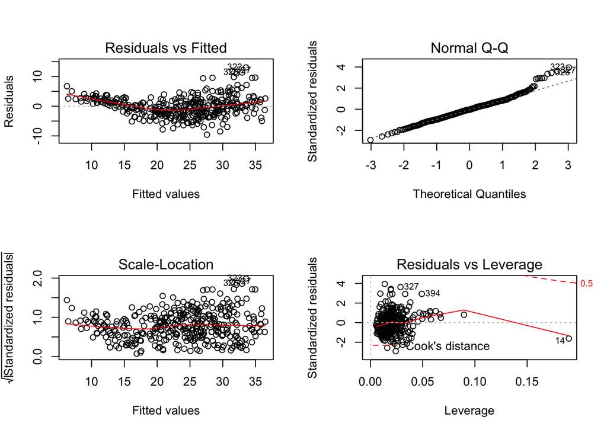

```r
par(mfrow = c(2, 2))
plot(lm09)
```

The plots indicate some potential outliers. Observation 14 has high leverage but a low residual.

#### (e)

```r
lm09e <- lm(mpg ~ . : . , data = Auto[, 1:8])
summary(lm09e)
```

```
##
## Call:
## lm(formula = mpg ~ .:., data = Auto[, 1:8])
##
## Residuals:
##    Min     1Q Median     3Q    Max
##  -7.63  -1.45   0.06   1.27  11.14
##
## Coefficients:
##                              Estimate  Std. Error t value Pr(>|t|)
## (Intercept)                35.4788875  53.1357886    0.67   0.5047
## cylinders                   6.9885762   8.2479708    0.85   0.3974
## displacement               -0.4785387   0.1893534   -2.53   0.0119 *
## horsepower                  0.5034339   0.3469994    1.45   0.1477
## weight                      0.0041329   0.0175942    0.23   0.8144
## acceleration               -5.8591732   2.1736212   -2.70   0.0074 **
## year                        0.6974303   0.6096703    1.14   0.2534
## origin                    -20.8955704   7.0970905   -2.94   0.0034 **
## cylinders:displacement     -0.0033833   0.0064551   -0.52   0.6005
## cylinders:horsepower        0.0116133   0.0241981    0.48   0.6316
## cylinders:weight            0.0003575   0.0008955    0.40   0.6900
## cylinders:acceleration      0.2778720   0.1664216    1.67   0.0958 .
## cylinders:year             -0.1741259   0.0971413   -1.79   0.0739 .
## cylinders:origin            0.4021682   0.4926224    0.82   0.4148
## displacement:horsepower    -0.0000849   0.0002885   -0.29   0.7687
## displacement:weight         0.0000247   0.0000147    1.68   0.0934 .
## displacement:acceleration  -0.0034790   0.0033417   -1.04   0.2985
## displacement:year           0.0059338   0.0023907    2.48   0.0135 *
## displacement:origin         0.0239811   0.0194653    1.23   0.2187
## horsepower:weight          -0.0000197   0.0000292   -0.67   0.5012
## horsepower:acceleration    -0.0072127   0.0037194   -1.94   0.0533 .
## horsepower:year            -0.0058375   0.0039385   -1.48   0.1392
## horsepower:origin           0.0022325   0.0293014    0.08   0.9393
## weight:acceleration         0.0002346   0.0002289    1.03   0.3060
## weight:year                -0.0002245   0.0002127   -1.06   0.2918
## weight:origin              -0.0005788   0.0015912   -0.36   0.7162
## acceleration:year           0.0556215   0.0255817    2.17   0.0303 *
## acceleration:origin         0.4583161   0.1566597    2.93   0.0037 **
## year:origin                 0.1392570   0.0739895    1.88   0.0606 .
## ---
## Signif. codes:  0 '***' 0.001 '**' 0.01 '*' 0.05 '.' 0.1 ' ' 1
##
## Residual standard error: 2.69 on 363 degrees of freedom
## Multiple R-squared:  0.889,  Adjusted R-squared:  0.881
## F-statistic:  104 on 28 and 363 DF,  p-value: <2e-16
```

#### (f)

Skip

### Question 10

#### (a)

```r
lm10 <- lm(Sales ~ Price + Urban + US, data = Carseats)
summary(lm10)
```

```
##
## Call:
## lm(formula = Sales ~ Price + Urban + US, data = Carseats)
##
## Residuals:
##    Min     1Q Median     3Q    Max
## -6.921 -1.622 -0.056  1.579  7.058
##
## Coefficients:
##             Estimate Std. Error t value  Pr(>|t|)
## (Intercept) 13.04347    0.65101   20.04   < 2e-16 ***
## Price       -0.05446    0.00524  -10.39   < 2e-16 ***
## UrbanYes    -0.02192    0.27165   -0.08      0.94
## USYes        1.20057    0.25904    4.63 0.0000049 ***
## ---
## Signif. codes:  0 '***' 0.001 '**' 0.01 '*' 0.05 '.' 0.1 ' ' 1
##
## Residual standard error: 2.47 on 396 degrees of freedom
## Multiple R-squared:  0.239,  Adjusted R-squared:  0.234
## F-statistic: 41.5 on 3 and 396 DF,  p-value: <2e-16
```

#### (b)

The results suggests:

1. A statistically significant negative relationship between `Sales` and `price`
2. No relationship between `Sales` and whether the store is located in an urban area
3. A statistically significant positive relationship between `Sales` and whether the store is located in the U.S.

#### (c)

The model can be written:
$$Sales = \beta_0 + \beta_1 \cdot Price + \beta_1 \cdot I_{Urban} + \beta_2 \cdot I_{US}$$

#### (d)

The null hypothesis that the coefficient is zero can be rejected for `Price` and `US`.

#### (e)

```r
lm10e <- lm(Sales ~ Price + US, data = Carseats)
summary(lm10e)
```

```
##
## Call:
## lm(formula = Sales ~ Price + US, data = Carseats)
##
## Residuals:
##    Min     1Q Median     3Q    Max
## -6.927 -1.629 -0.057  1.577  7.052
##
## Coefficients:
##             Estimate Std. Error t value  Pr(>|t|)
## (Intercept) 13.03079    0.63098   20.65   < 2e-16 ***
## Price       -0.05448    0.00523  -10.42   < 2e-16 ***
## USYes        1.19964    0.25846    4.64 0.0000047 ***
## ---
## Signif. codes:  0 '***' 0.001 '**' 0.01 '*' 0.05 '.' 0.1 ' ' 1
##
## Residual standard error: 2.47 on 397 degrees of freedom
## Multiple R-squared:  0.239,  Adjusted R-squared:  0.235
## F-statistic: 62.4 on 2 and 397 DF,  p-value: <2e-16
```

#### (f)

The second model has the same $R^2$ but a lower $RSE$.

#### (g)

```r
confint(lm10e)
```

```
##                2.5 %    97.5 %
## (Intercept) 11.79032 14.271265
## Price       -0.06476 -0.044195
## USYes        0.69152  1.707766
```

#### (h)

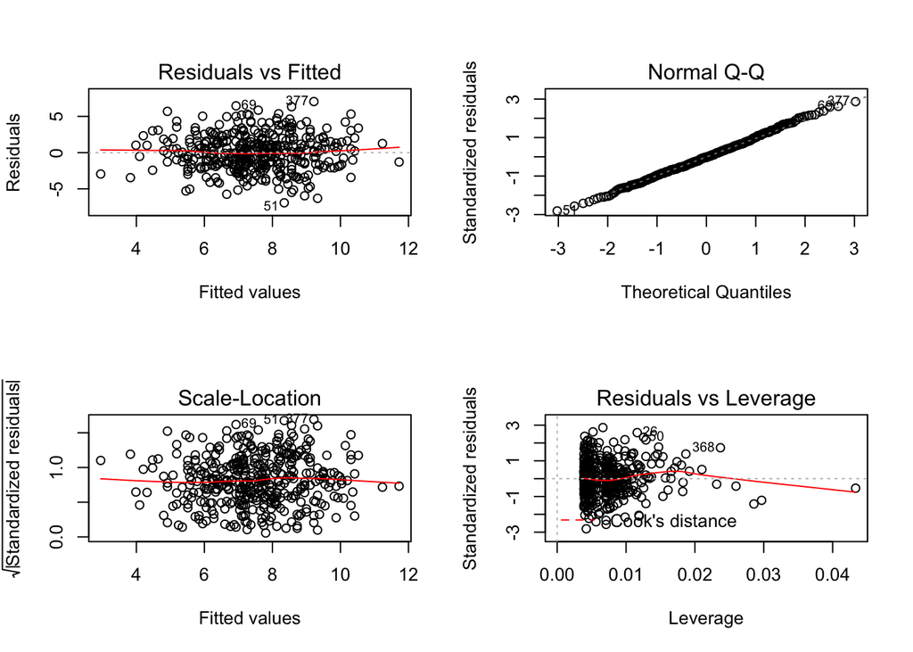

```r
par(mfrow = c(2, 2))
plot(lm10e)
```

A few points have high leverage but low residuals.

### Question 11

```r
set.seed(1)
x <- rnorm(100)
y <- 2 * x + rnorm(100)
```

#### (a)

```r
lm11 <- lm(y ~ x + 0)
summary(lm11)
```

```
##
## Call:
## lm(formula = y ~ x + 0)
##
## Residuals:
##    Min     1Q Median     3Q    Max
## -1.915 -0.647 -0.177  0.506  2.311
##
## Coefficients:
##   Estimate Std. Error t value Pr(>|t|)
## x    1.994      0.106    18.7   <2e-16 ***
## ---
## Signif. codes:  0 '***' 0.001 '**' 0.01 '*' 0.05 '.' 0.1 ' ' 1
##
## Residual standard error: 0.959 on 99 degrees of freedom
## Multiple R-squared:  0.78,   Adjusted R-squared:  0.778
## F-statistic:  351 on 1 and 99 DF,  p-value: <2e-16
```

#### (b)

```r
lm11b <- lm(x ~ y + 0)
summary(lm11b)
```

```
##
## Call:
## lm(formula = x ~ y + 0)
##
## Residuals:
##    Min     1Q Median     3Q    Max
## -0.870 -0.237  0.103  0.286  0.894
##
## Coefficients:
##   Estimate Std. Error t value Pr(>|t|)
## y   0.3911     0.0209    18.7   <2e-16 ***
## ---
## Signif. codes:  0 '***' 0.001 '**' 0.01 '*' 0.05 '.' 0.1 ' ' 1
##
## Residual standard error: 0.425 on 99 degrees of freedom
## Multiple R-squared:  0.78,   Adjusted R-squared:  0.778
## F-statistic:  351 on 1 and 99 DF,  p-value: <2e-16
```

#### (d)

```r
sqrt(length(x) - 1) * sum(x * y) /
  sqrt(sum(x ^ 2) * sum(y ^ 2) - (sum(x * y)) ^ 2)
```

```
## [1] 18.726
```

#### (e)

Relabeling `x` and `y` in the equation above does not effect the results.

#### (f)

```r
lm11f1 <- lm(y ~ x)
summary(lm11f1)
```

```
##
## Call:
## lm(formula = y ~ x)
##
## Residuals:
##    Min     1Q Median     3Q    Max
## -1.877 -0.614 -0.140  0.539  2.346
##
## Coefficients:
##             Estimate Std. Error t value Pr(>|t|)
## (Intercept)  -0.0377     0.0970   -0.39      0.7
## x             1.9989     0.1077   18.56   <2e-16 ***
## ---
## Signif. codes:  0 '***' 0.001 '**' 0.01 '*' 0.05 '.' 0.1 ' ' 1
##
## Residual standard error: 0.963 on 98 degrees of freedom
## Multiple R-squared:  0.778,  Adjusted R-squared:  0.776
## F-statistic:  344 on 1 and 98 DF,  p-value: <2e-16
```

```r
lm11f2 <- lm(x ~ y)
summary(lm11f2)
```

```
##
## Call:
## lm(formula = x ~ y)
##
## Residuals:
##     Min      1Q  Median      3Q     Max
## -0.9085 -0.2810  0.0627  0.2457  0.8574
##
## Coefficients:
##             Estimate Std. Error t value Pr(>|t|)
## (Intercept)   0.0388     0.0427    0.91     0.37
## y             0.3894     0.0210   18.56   <2e-16 ***
## ---
## Signif. codes:  0 '***' 0.001 '**' 0.01 '*' 0.05 '.' 0.1 ' ' 1
##
## Residual standard error: 0.425 on 98 degrees of freedom
## Multiple R-squared:  0.778,  Adjusted R-squared:  0.776
## F-statistic:  344 on 1 and 98 DF,  p-value: <2e-16
```

```r
all.equal(summary(lm11f1)[[4]][2, 3], summary(lm11f2)[[4]][2, 3])
```

```
## [1] TRUE
```

### Question 12

#### (a)

If it is the case that $\sum_1^n x_i^2 = \sum_1^n y_i^2$ then the coefficients will be equal.

#### (b)

See parts (a) and (b) from Question 11.

#### (c)

```r
x <- rnorm(100)
y <- sample(x, 100, replace = F)
lm12c1 <- lm(y ~ x + 0)
summary(lm12c1)
```

```
##
## Call:
## lm(formula = y ~ x + 0)
##
## Residuals:
##    Min     1Q Median     3Q    Max
## -2.899 -0.457  0.036  0.684  2.656
##
## Coefficients:
##   Estimate Std. Error t value Pr(>|t|)
## x   0.0274     0.1005    0.27     0.79
##
## Residual standard error: 1.03 on 99 degrees of freedom
## Multiple R-squared:  0.00075,    Adjusted R-squared:  -0.00934
## F-statistic: 0.0743 on 1 and 99 DF,  p-value: 0.786
```

```r
lm12c2 <- lm(x ~ y + 0)
summary(lm12c2)
```

```
##
## Call:
## lm(formula = x ~ y + 0)
##
## Residuals:
##     Min      1Q  Median      3Q     Max
## -2.9383 -0.4816  0.0142  0.6924  2.6493
##
## Coefficients:
##   Estimate Std. Error t value Pr(>|t|)
## y   0.0274     0.1005    0.27     0.79
##
## Residual standard error: 1.03 on 99 degrees of freedom
## Multiple R-squared:  0.00075,    Adjusted R-squared:  -0.00934
## F-statistic: 0.0743 on 1 and 99 DF,  p-value: 0.786
```

### Question 13

#### (a)

```r
X <- rnorm(100, 0, 1)
```

#### (b)

```r
eps <- rnorm(100, 0, 0.25)
```

#### (c)

```r
Y <- -1 + 0.5 * X + eps
```

The vector `Y` has the same length as `X`. In this case, $\beta_0 = -1$ and $\beta_1 = 0.5$.

#### (d)

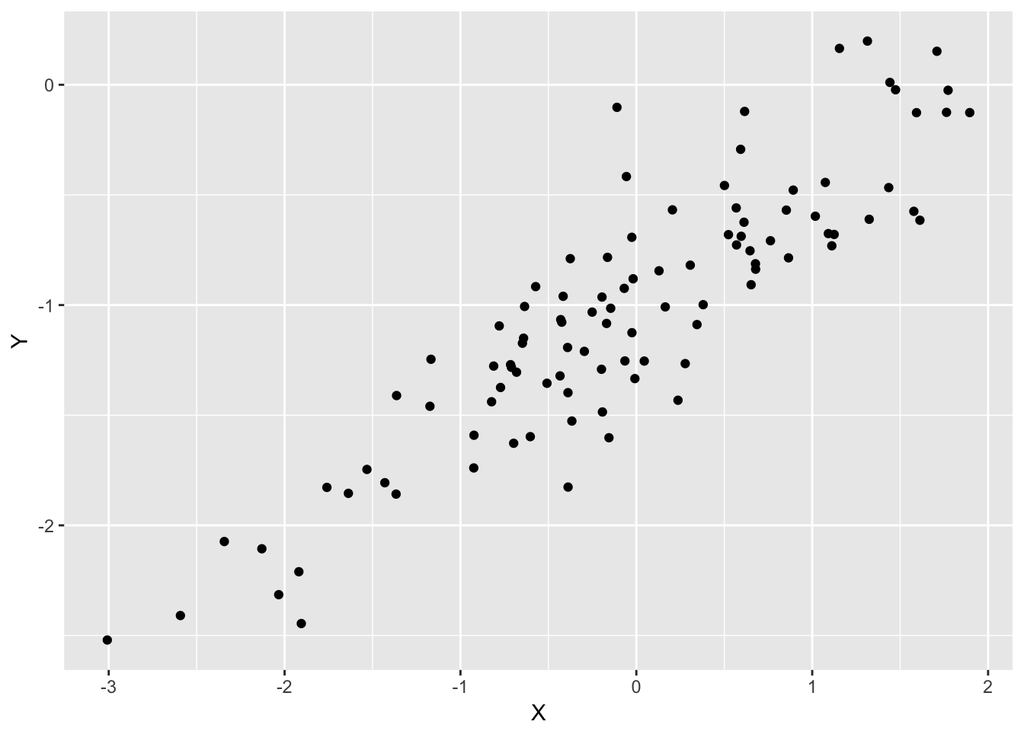

```r
qplot(X, Y)
```

There is a clear linear relationshihp between `X` and `Y` subject to noise.

#### (e)

```r
lm13 <- lm(Y ~ X)
summary(lm13)
```

```
##
## Call:
## lm(formula = Y ~ X)
##
## Residuals:
##    Min     1Q Median     3Q    Max
## -0.626 -0.198  0.006  0.142  0.955
##
## Coefficients:
##             Estimate Std. Error t value Pr(>|t|)
## (Intercept)  -1.0014     0.0275   -36.4   <2e-16 ***
## X             0.5126     0.0263    19.5   <2e-16 ***
## ---
## Signif. codes:  0 '***' 0.001 '**' 0.01 '*' 0.05 '.' 0.1 ' ' 1
##
## Residual standard error: 0.275 on 98 degrees of freedom
## Multiple R-squared:  0.795,  Adjusted R-squared:  0.793
## F-statistic:  380 on 1 and 98 DF,  p-value: <2e-16
```

The estimated $\beta_0$ and $\beta_1$ are close to their actual values.

#### (f)

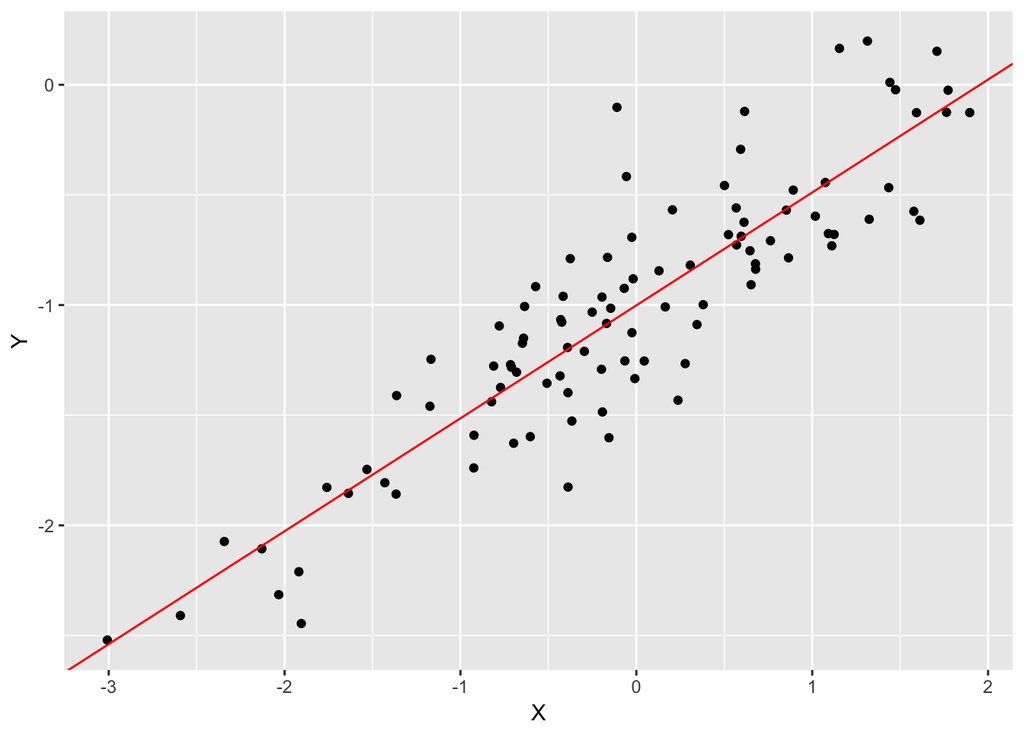

```r
p <- ggplot(tibble(X, Y)) +
  geom_point(aes(X, Y)) +
  geom_abline(aes(intercept = coef(lm13)[1], slope = coef(lm13)[2]), col = 'red')
p
```

#### (g)

```r
lm13g <- lm(Y ~ X + I(X ^ 2))
summary(lm13g)
```

```
##
## Call:
## lm(formula = Y ~ X + I(X^2))
##
## Residuals:
##     Min      1Q  Median      3Q     Max
## -0.6402 -0.2031  0.0064  0.1406  0.9409
##
## Coefficients:
##             Estimate Std. Error t value Pr(>|t|)
## (Intercept)  -0.9875     0.0341  -28.92   <2e-16 ***
## X             0.5063     0.0279   18.15   <2e-16 ***
## I(X^2)       -0.0132     0.0189   -0.69     0.49
## ---
## Signif. codes:  0 '***' 0.001 '**' 0.01 '*' 0.05 '.' 0.1 ' ' 1
##
## Residual standard error: 0.275 on 97 degrees of freedom
## Multiple R-squared:  0.796,  Adjusted R-squared:  0.792
## F-statistic:  189 on 2 and 97 DF,  p-value: <2e-16
```

The polynomial regression offers no discernable improvement in fit.

### Question 14

#### (a)

```r
set.seed(1)
x1 <- runif(100)
x2 <- 0.5 * x1 + rnorm(100) / 10
y  <- 2 + 2 * x1 + 0.3 * x2 + rnorm(100)
```

$\beta_0 = 2$, $\beta_1 = 2$, and $\beta_3 = 0.3$.

#### (b)

```r
cor(x1, x2)
```

```
## [1] 0.83512
```

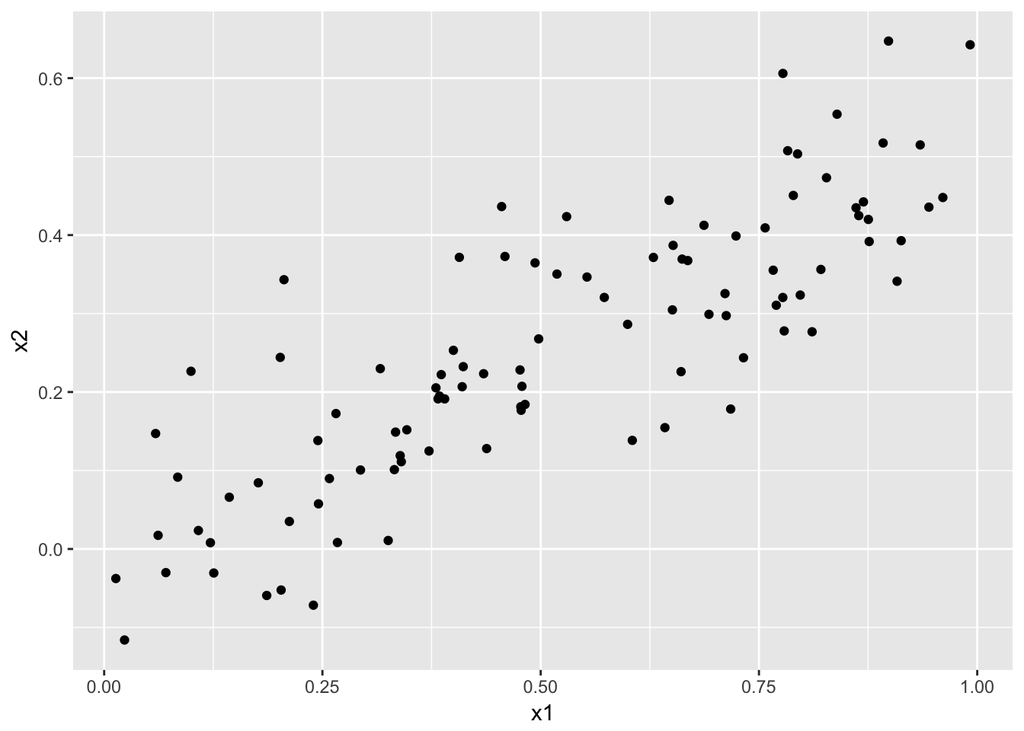

```r
qplot(x1, x2)
```

#### (c)

```r
lm14c <- lm(y ~ x1 + x2)
summary(lm14c)
```

```
##
## Call:
## lm(formula = y ~ x1 + x2)
##
## Residuals:
##     Min      1Q  Median      3Q     Max
## -2.8311 -0.7273 -0.0537  0.6338  2.3359
##
## Coefficients:
##             Estimate Std. Error t value Pr(>|t|)
## (Intercept)    2.130      0.232    9.19  7.6e-15 ***
## x1             1.440      0.721    2.00    0.049 *
## x2             1.010      1.134    0.89    0.375
## ---
## Signif. codes:  0 '***' 0.001 '**' 0.01 '*' 0.05 '.' 0.1 ' ' 1
##
## Residual standard error: 1.06 on 97 degrees of freedom
## Multiple R-squared:  0.209,  Adjusted R-squared:  0.193
## F-statistic: 12.8 on 2 and 97 DF,  p-value: 0.0000116
```

$\beta_0 = 2.1305$, $\beta_1 = 1.4396$, and $\beta_3 = 1.0097$. We can reject the null hypothesis for $\beta_1$ but not $\beta_2$.

#### (d)

```r
lm14d <- lm(y ~ x1)
summary(lm14d)
```

```
##
## Call:
## lm(formula = y ~ x1)
##
## Residuals:
##     Min      1Q  Median      3Q     Max
## -2.8950 -0.6687 -0.0779  0.5922  2.4556
##
## Coefficients:
##             Estimate Std. Error t value Pr(>|t|)
## (Intercept)    2.112      0.231    9.15  8.3e-15 ***
## x1             1.976      0.396    4.99  2.7e-06 ***
## ---
## Signif. codes:  0 '***' 0.001 '**' 0.01 '*' 0.05 '.' 0.1 ' ' 1
##
## Residual standard error: 1.06 on 98 degrees of freedom
## Multiple R-squared:  0.202,  Adjusted R-squared:  0.194
## F-statistic: 24.9 on 1 and 98 DF,  p-value: 0.00000266
```

We can reject the null hypothesis for $\beta_1$.

#### (e)

```r
lm14e <- lm(y ~ x2)
summary(lm14e)
```

```
##
## Call:
## lm(formula = y ~ x2)
##
## Residuals:
##    Min     1Q Median     3Q    Max
## -2.627 -0.752 -0.036  0.724  2.449
##
## Coefficients:
##             Estimate Std. Error t value Pr(>|t|)
## (Intercept)    2.390      0.195   12.26  < 2e-16 ***
## x2             2.900      0.633    4.58 0.000014 ***
## ---
## Signif. codes:  0 '***' 0.001 '**' 0.01 '*' 0.05 '.' 0.1 ' ' 1
##
## Residual standard error: 1.07 on 98 degrees of freedom
## Multiple R-squared:  0.176,  Adjusted R-squared:  0.168
## F-statistic:   21 on 1 and 98 DF,  p-value: 0.0000137
```

We can reject the null hypothesis for $\beta_1$.

#### (f)

No. `x1` and `x2` are collinear so the results make sense.

#### (g)

```r
x1 <- c(x1, 0.1)
x2 <- c(x2, 0.8)
y  <- c(y, 6)
lm14g1 <- lm(y ~ x1 + x2)
summary(lm14g1)
```

```
##
## Call:
## lm(formula = y ~ x1 + x2)
##
## Residuals:
##     Min      1Q  Median      3Q     Max
## -2.7335 -0.6932 -0.0526  0.6638  2.3062
##
## Coefficients:
##             Estimate Std. Error t value Pr(>|t|)
## (Intercept)    2.227      0.231    9.62  7.9e-16 ***
## x1             0.539      0.592    0.91   0.3646
## x2             2.515      0.898    2.80   0.0061 **
## ---
## Signif. codes:  0 '***' 0.001 '**' 0.01 '*' 0.05 '.' 0.1 ' ' 1
##
## Residual standard error: 1.07 on 98 degrees of freedom
## Multiple R-squared:  0.219,  Adjusted R-squared:  0.203
## F-statistic: 13.7 on 2 and 98 DF,  p-value: 0.00000556
```

```r
lm14g2 <- lm(y ~ x1)
summary(lm14g2)
```

```
##
## Call:
## lm(formula = y ~ x1)
##
## Residuals:
##    Min     1Q Median     3Q    Max
## -2.890 -0.656 -0.091  0.568  3.567
##
## Coefficients:
##             Estimate Std. Error t value Pr(>|t|)
## (Intercept)    2.257      0.239    9.44  1.8e-15 ***
## x1             1.766      0.412    4.28  4.3e-05 ***
## ---
## Signif. codes:  0 '***' 0.001 '**' 0.01 '*' 0.05 '.' 0.1 ' ' 1
##
## Residual standard error: 1.11 on 99 degrees of freedom
## Multiple R-squared:  0.156,  Adjusted R-squared:  0.148
## F-statistic: 18.3 on 1 and 99 DF,  p-value: 0.0000429
```

```r
lm14g3 <- lm(y ~ x2)
summary(lm14g3)
```

```
##
## Call:
## lm(formula = y ~ x2)
##
## Residuals:
##    Min     1Q Median     3Q    Max
## -2.647 -0.710 -0.069  0.727  2.381
##
## Coefficients:
##             Estimate Std. Error t value  Pr(>|t|)
## (Intercept)    2.345      0.191   12.26   < 2e-16 ***
## x2             3.119      0.604    5.16 0.0000013 ***
## ---
## Signif. codes:  0 '***' 0.001 '**' 0.01 '*' 0.05 '.' 0.1 ' ' 1
##
## Residual standard error: 1.07 on 99 degrees of freedom
## Multiple R-squared:  0.212,  Adjusted R-squared:  0.204
## F-statistic: 26.7 on 1 and 99 DF,  p-value: 0.00000125
```

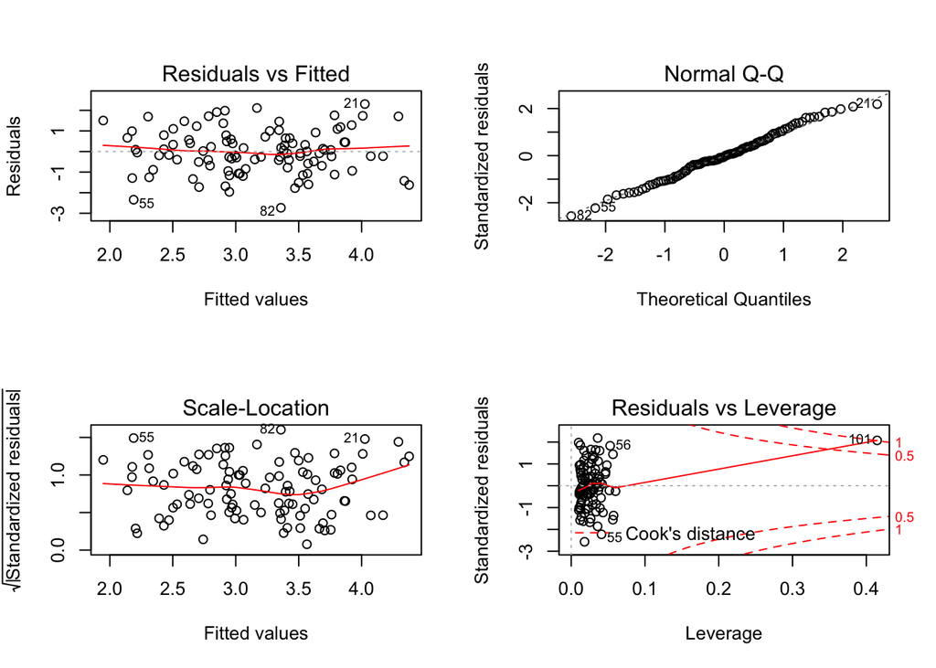

```r
par(mfrow = c(2, 2))
plot(lm14g1)
```

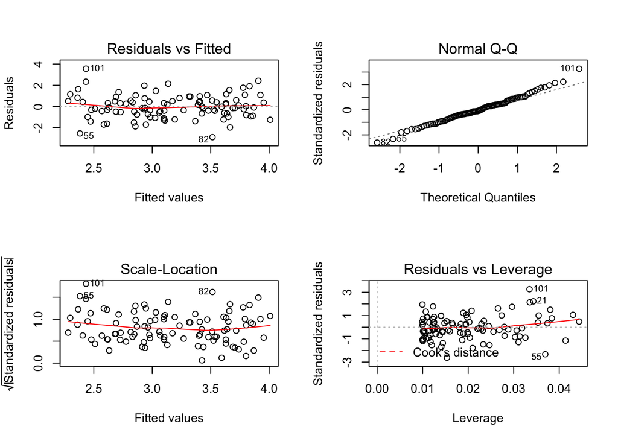

```r
plot(lm14g2)
```

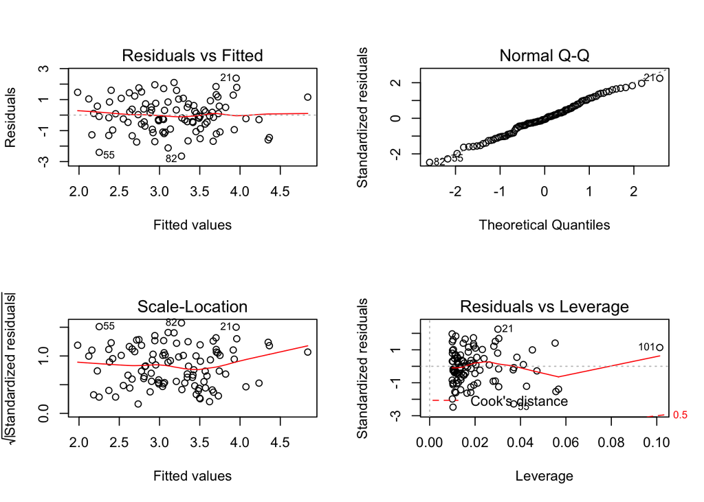

```r
plot(lm14g3)
```

In the second model, the new observation is an outlier. In the first and third models, the new observation is a high leverage point.

### Question 15

#### (a)

Skip

#### (b)

```r
lm15 <- lm(crim ~ ., data = Boston)
summary(lm15)
```

```
##
## Call:
## lm(formula = crim ~ ., data = Boston)
##
## Residuals:
##    Min     1Q Median     3Q    Max
##  -9.92  -2.12  -0.35   1.02  75.05
##
## Coefficients:
##              Estimate Std. Error t value Pr(>|t|)
## (Intercept)  17.03323    7.23490    2.35   0.0189 *
## zn            0.04486    0.01873    2.39   0.0170 *
## indus        -0.06385    0.08341   -0.77   0.4443
## chas         -0.74913    1.18015   -0.63   0.5259
## nox         -10.31353    5.27554   -1.95   0.0512 .
## rm            0.43013    0.61283    0.70   0.4831
## age           0.00145    0.01793    0.08   0.9355
## dis          -0.98718    0.28182   -3.50   0.0005 ***
## rad           0.58821    0.08805    6.68  6.5e-11 ***
## tax          -0.00378    0.00516   -0.73   0.4638
## ptratio      -0.27108    0.18645   -1.45   0.1466
## black        -0.00754    0.00367   -2.05   0.0407 *
## lstat         0.12621    0.07572    1.67   0.0962 .
## medv         -0.19889    0.06052   -3.29   0.0011 **
## ---
## Signif. codes:  0 '***' 0.001 '**' 0.01 '*' 0.05 '.' 0.1 ' ' 1
##
## Residual standard error: 6.44 on 492 degrees of freedom
## Multiple R-squared:  0.454,  Adjusted R-squared:  0.44
## F-statistic: 31.5 on 13 and 492 DF,  p-value: <2e-16
```

#### (c)

Skip

#### (d)

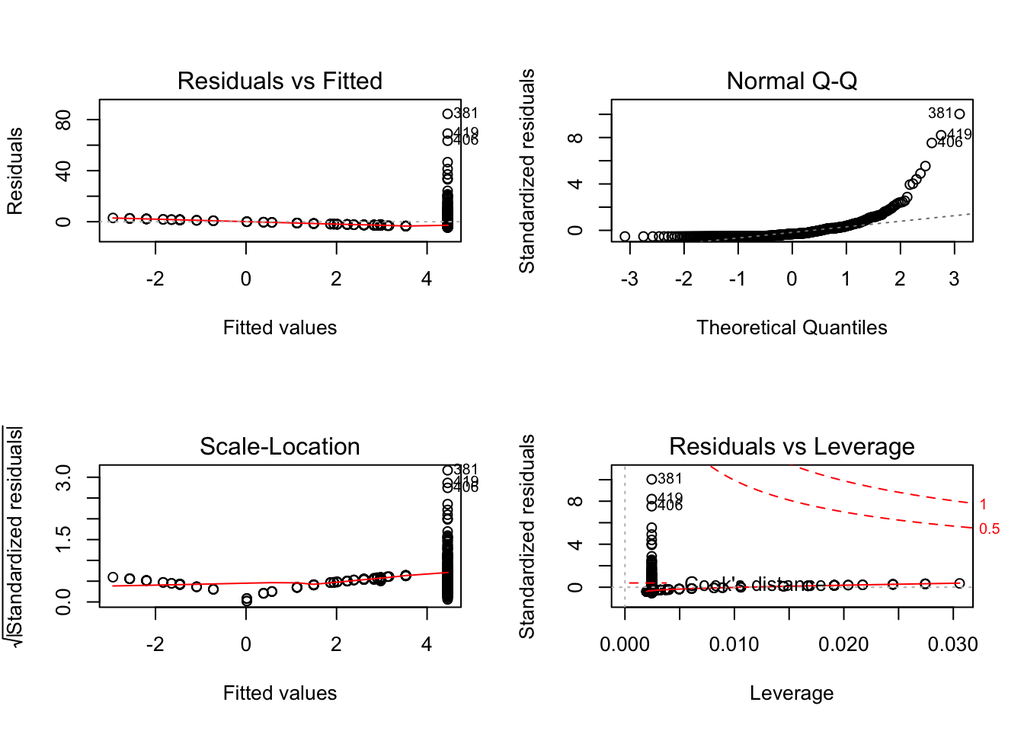

```r
lm15d1 <- lm(crim ~ zn, data = Boston)
par(mfrow = c(2, 2))
plot(lm15d1)
```

```r
summary(lm15d1)
```

```
##
## Call:
## lm(formula = crim ~ zn, data = Boston)
##
## Residuals:
##    Min     1Q Median     3Q    Max
##  -4.43  -4.22  -2.62   1.25  84.52
##
## Coefficients:
##             Estimate Std. Error t value  Pr(>|t|)
## (Intercept)   4.4537     0.4172   10.67   < 2e-16 ***
## zn           -0.0739     0.0161   -4.59 0.0000055 ***
## ---
## Signif. codes:  0 '***' 0.001 '**' 0.01 '*' 0.05 '.' 0.1 ' ' 1
##
## Residual standard error: 8.44 on 504 degrees of freedom
## Multiple R-squared:  0.0402, Adjusted R-squared:  0.0383
## F-statistic: 21.1 on 1 and 504 DF,  p-value: 0.00000551
```

```r
lm15d2 <- lm(crim ~ poly(zn, 3), data = Boston)
summary(lm15d2)
```

```
##
## Call:
## lm(formula = crim ~ poly(zn, 3), data = Boston)
##
## Residuals:
##    Min     1Q Median     3Q    Max
##  -4.82  -4.61  -1.29   0.47  84.13
##
## Coefficients:
##              Estimate Std. Error t value  Pr(>|t|)
## (Intercept)     3.614      0.372    9.71   < 2e-16 ***
## poly(zn, 3)1  -38.750      8.372   -4.63 0.0000047 ***
## poly(zn, 3)2   23.940      8.372    2.86    0.0044 **
## poly(zn, 3)3  -10.072      8.372   -1.20    0.2295
## ---
## Signif. codes:  0 '***' 0.001 '**' 0.01 '*' 0.05 '.' 0.1 ' ' 1
##
## Residual standard error: 8.37 on 502 degrees of freedom
## Multiple R-squared:  0.0582, Adjusted R-squared:  0.0526
## F-statistic: 10.3 on 3 and 502 DF,  p-value: 0.00000128
```